[figure not shown]

SC(STI)-2

General Description

STARTING/CHARGING SYSTEMS

1. General Description

A: SPECIFICATION

Item Specifications

Starter

Type Reduction type

Model 428000-5760

Manufacturer DENSO

Voltage and output 12 V — 1.0 kW

Direction of rotation Counterclockwise (when observed from pinion)

Number of pinion teeth 9

Armature commutator

runout

Standard 0.05 mm (0.0020 in)

Limit 0.10 mm (0.0039 in)

Armature depth of seg-

ment mold

Standard 0.5 mm (0.020 in)

Brush length

Standard 12.3 mm (0.484 in)

Limit 7.0 mm (0.276 in)

Brush spring force

Standard 15.9 — 19.5 N (1.62 — 1.99 kgf, 3.57 — 4.38 lbf)

Limit 2.5 N (0.25 kgf, 0.56 lbf)

No-load characteristics

Voltage 11 V

Current 90 A or less

Rotating speed 2,860 rpm or more

Load characteristics

Voltage 8 V

Current 280 A

Torque 9.3 N·m (0.9 kgf-m, 6.9 ft-lb) or more

Rotating speed 860 rpm or more

Lock characteristics

Voltage 4 V

Current 515 A or less

Torque 16 N·m (1.6 kgf-m, 11.8 ft-lb) or more

Generator

Type

Rotating-field three-phase type, voltage regulator built-in type,

with load response control system

Model A3TG6591

Manufacturer Mitsubishi Electric

Voltage and output 12 V — 110 A

Polarity on ground side Negative

Direction of rotation Clockwise (when observed from pulley side)

Stator connection 3-phase Y-type

Output current

1,500 rpm — 50 A or more

2,500 rpm — 91 A or more

5,000 rpm — 105 A or more

Regulated voltage 14.1 — 14.8 V [20°C (68°F)]

Rotor slip ring outer

diameter

Standard 22.7 mm (0.894 in)

Limit 22.1 mm (0.870 in)

Brush length

Standard 18.5 mm (0.728 in)

Limit 5.0 mm (0.197 in)

Battery

Type and capacity 12 V — 48 AH (55D23L)

CCA 390 A

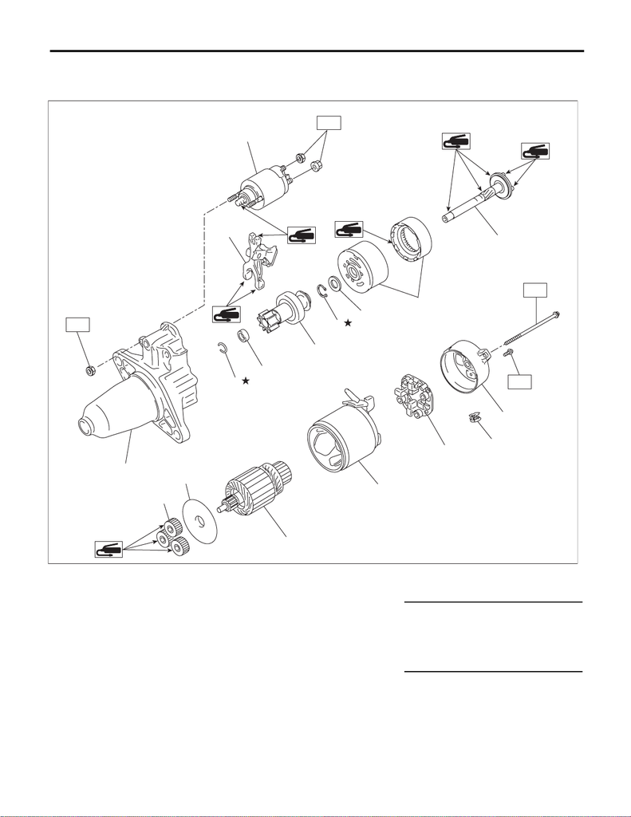

SC(STI)-3

General Description

STARTING/CHARGING SYSTEMS

B: COMPONENT

1. STARTER

(1) Starter housing ASSY (9) Pinion gear (17) Magnet switch ASSY

(2) Snap ring (10) Starter plate

(3) Stopper (11) Armature Tightening torque: N·m (kgf-m, ft-lb)

(4) Overrunning clutch (12) Yoke ASSY T1: 1.4 (0.1, 1.0)

(5) Snap ring (13) Brush holder ASSY T2: 6 (0.6, 4.4)

(6) Washer (14) Starter cover ASSY T3: 7.5 (0.8, 5.5)

(7) Internal gear ASSY (15) Drain duct T4: 10 (1.0, 7.4)

(8) Shaft (16) Shift lever

SC-02448

(12)

(13)

T1

T3

T4

T2

(1)

(2)

(3)

(4)

(5)

(6)

(7)

(8)

(9)

(10)

(11)

(14)

(15)

(16)

(17)

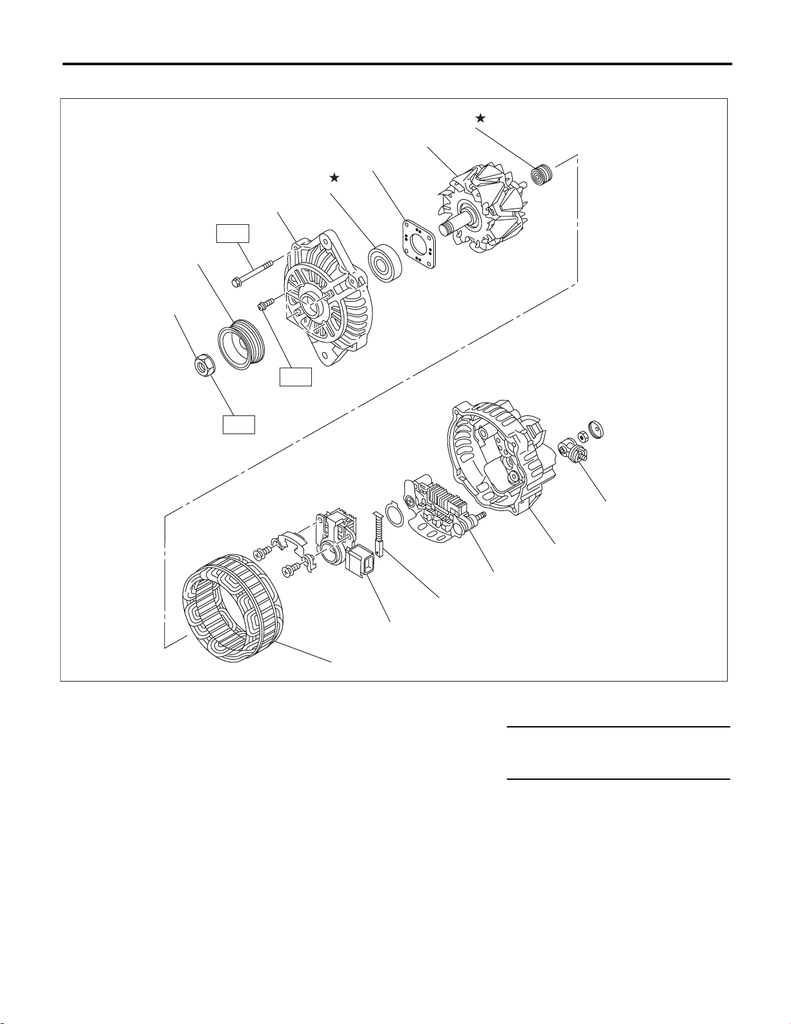

SC(STI)-4

General Description

STARTING/CHARGING SYSTEMS

2. GENERATOR

(1) Pulley nut (7) Bearing (13) Terminal B

(2) Pulley (8) Stator coil

(3) Front cover (9) IC regulator Tightening torque: N·m (kgf-m, ft-lb)

(4) Ball bearing (10) Brush T1: 4.7 (0.5, 3.5)

(5) Bearing retainer (11) Rectifier T2: 108 (11.0, 79.8)

(6) Rotor (12) Rear cover

(1)

(2)

(3)

(4)

(5)

(6)

(7)

(8)

(9)

(10)

(11)

(12)

(13)

T1

T1

T2

SC-00163

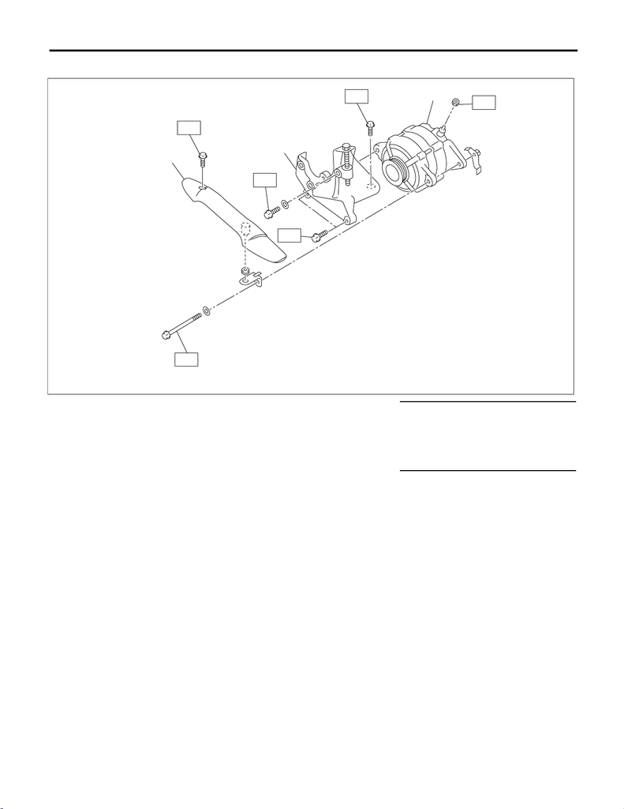

SC(STI)-5

General Description

STARTING/CHARGING SYSTEMS

3. GENERATOR BRACKET

(1) Generator (3) V-belt cover Tightening torque: N·m (kgf-m, ft-lb)

(2) Power steering pump bracket T1: 13 (1.3, 9.6)

T2: 16 (1.6, 11.8)

T3: 22 (2.2, 16.2)

T4: 25 (2.5, 18.4)

SC-02440

(1)

(2)

(3)

T1

T4

T4

T2

T3

T3

[figure not shown]

SC(STI)-6

General Description

STARTING/CHARGING SYSTEMS

C: CAUTION

• Prior to starting work, pay special attention to the following:

1. Always wear work clothes, a work cap, and protective shoes. Additionally, wear a helmet, protective

goggles, etc. if necessary.

2. Protect the vehicle using a seat cover, fender cover, etc.

3. Prepare the service tools, clean cloth, containers to catch grease and oil, etc.

• Vehicle components are extremely hot immediately after driving. Be wary of receiving burns from heated

parts.

• When performing a repair, identify the cause of trouble and avoid unnecessary removal, disassembly and

replacement.

• Before disconnecting connectors of sensors or units, be sure to disconnect the ground cable from battery.

• Always use the jack-up point when the shop jacks or rigid racks are used to support the vehicle.

• Remove contamination including dirt and corrosion before removal, installation, disassembly or assembly.

• Keep the removed parts in order and protect them from dust and dirt.

• All removed parts, if to be reused, should be reinstalled in the original positions with attention to the correct

directions, etc.

• Bolts, nuts and washers should be replaced with new parts as required.

• Be sure to tighten the fasteners including bolts and nuts to the specified torque.

D: PREPARATION TOOL

1. GENERAL TOOL

TOOL NAME REMARKS

Circuit tester Used for measuring resistance, voltage and current.